# Discovering Bestsellers with R

### Cleaning, analysing and visualizing data

*By Alexandre Kocev*

Blue Island is a shipping company operating all over the world and selling a large variety of products.  
The purpose of this analysis is to determine the best sellers in terms of revenue for each geographical areas. The final results will be presented to the Operations and Marketing vice presidents allowing them to adapt their supply and marketing strategies for each geographical area. The final goal is to increase sales by selecting the best products for each region as well as to limit shipping and storage costs.  
The data is made of the last four years of sales records. Each annual record is contained into one csv file.

*The original data was created by Jonathan Major and collected from [here](https://data.world/bobmajor/sales). It was then reorganized by myself for the purpose of this case study.*

## STEP 1 : Set up the workspace and read the data

Import required packages.

```r
library(tidyverse) #wrangle data
library(lubridate) #convert date attribute
library(dplyr) #manipulate data
library(ggplot2) #visualize data
library(scales) #calculate values as percent and currency
library(gridExtra) #arrange graphs
library(knitr) #draw tables on rmarkdown
```

Upload four csv files as Blue Island sales records.

```r
sales_2017 <- read.csv('2017_sales_record.csv')
sales_2018 <- read.csv('2018_sales_record.csv')
sales_2019 <- read.csv('2019_sales_record.csv')
sales_2020 <- read.csv('2020_sales_record.csv')
```

## STEP 2 : Combine into a single dataframe

### (1) Rename column names

Column names do not need to be in the same order but their name have to match perfectly in order to join them.

```r
colnames(sales_2017)
```

```
##  [1] "Region"     "Country"    "Type"       "Channel"    "Priority"
##  [6] "Order.Date" "Order.ID"   "Ship.Date"  "Sold"       "Price"
## [11] "Cost"
```

```r
colnames(sales_2018)
```

```
##  [1] "Region"         "Country"        "Type"           "Channel"
##  [5] "Priority"       "Order.Date"     "Order.ID"       "Ship.Date"
##  [9] "Sold.Items"     "Price.per.Item" "Cost.per.Item"
```

```r
colnames(sales_2019)
```

```
##  [1] "Region"            "Country"           "Type"
##  [4] "Channel.of.Sales"  "Priority.of.Order" "Order.Date"
##  [7] "Order.ID"          "Ship.Date"         "Sold.Items"
## [10] "Price.per.Item"    "Cost.per.Item"
```

```r
colnames(sales_2020)
```

```
##  [1] "Region"            "Country"           "Type.of.Product"
##  [4] "Channel.of.Sales"  "Priority.of.Order" "Order.Date"
##  [7] "Order.ID"          "Ship.Date"         "Sold.Items"
## [10] "Price"             "Cost"
```

Rename columns to make them consistent

```r
sales_2017 <- rename(sales_2017
                     ,region = Region
                     ,country   = Country
                     ,item_type = Type
                     ,sales_channel = Channel
                     ,order_priority    = Priority
                     ,order_date    = Order.Date
                     ,order_id  = Order.ID
                     ,ship_date = Ship.Date
                     ,units_sold    = Sold
                     ,unit_price    = Price
                     ,unit_cost = Cost)

sales_2018 <- rename(sales_2018
                     ,region = Region
                     ,country   = Country
                     ,item_type = Type
                     ,sales_channel = Channel
                     ,order_priority    = Priority
                     ,order_date    = Order.Date
                     ,order_id  = Order.ID
                     ,ship_date = Ship.Date
                     ,units_sold    = Sold.Items
                     ,unit_price    = Price.per.Item
                     ,unit_cost = Cost.per.Item)

sales_2019 <- rename(sales_2019
                     ,region = Region
                     ,country   = Country
                     ,item_type = Type
                     ,sales_channel = Channel.of.Sales
                     ,order_priority    = Priority.of.Order
                     ,order_date    = Order.Date
                     ,order_id  = Order.ID
                     ,ship_date = Ship.Date
                     ,units_sold    = Sold.Items
                     ,unit_price    = Price.per.Item
                     ,unit_cost = Cost.per.Item)

sales_2020 <- rename(sales_2020
                     ,region = Region
                     ,country   = Country
                     ,item_type = Type.of.Product
                     ,sales_channel = Channel.of.Sales
                     ,order_priority    = Priority.of.Order
                     ,order_date    = Order.Date
                     ,order_id  = Order.ID
                     ,ship_date = Ship.Date
                     ,units_sold    = Sold.Items
                     ,unit_price    = Price
                     ,unit_cost = Cost)
```

### (2) Look for inconstancy in data types

```r
str(sales_2017)
```

```
## 'data.frame':    660 obs. of  11 variables:
##  $ region        : chr  "Asia" "Asia" "Europe" "Europe" ...
##  $ country       : chr  "South Korea" "South Korea" "Estonia" "Cyprus" ...
##  $ item_type     : chr  "Baby Food" "Office Supplies" "Baby Food" "Personal Care" ...
##  $ sales_channel : chr  "Online" "Offline" "Offline" "Online" ...
##  $ order_priority: chr  "M" "H" "M" "L" ...
##  $ order_date    : chr  "1/1/2017" "1/1/2017" "1/2/2017" "1/2/2017" ...
##  $ order_id      : int  104548490 661543309 123086202 561534678 665518558 759151256 128990066 288941133 444798934 571531808 ...
##  $ ship_date     : chr  "1/5/2017" "1/20/2017" "2/20/2017" "1/29/2017" ...
##  $ units_sold    : int  7076 4221 2797 9445 585 8581 9882 2957 4744 7818 ...
##  $ unit_price    : num  52.06 130.24 50.56 16.55 2.97 ...
##  $ unit_cost     : num  32.68 104.89 31.08 13.33 2.38 ...
```

```r
str(sales_2018)
```

```
## 'data.frame':    739 obs. of  11 variables:
##  $ region        : chr  "North America" "North America" "Europe" "Europe" ...
##  $ country       : chr  "United States of America" "United States of America" "Belgium" "Slovenia" ...
##  $ item_type     : chr  "Fruits" "Cosmetics" "Cereal" "Personal Care" ...
##  $ sales_channel : chr  "Online" "Online" "Offline" "Offline" ...
##  $ order_priority: chr  "M" "C" "H" "M" ...
##  $ order_date    : chr  "11/22/2017" "11/22/2017" "11/22/2017" "11/23/2017" ...
##  $ order_id      : int  290980470 762883174 791890084 700304019 492100226 774926936 849431836 624736964 743283307 946921765 ...
##  $ ship_date     : chr  "1/1/2018" "11/29/2017" "12/15/2017" "12/21/2017" ...
##  $ units_sold    : int  6442 2939 6728 4376 2247 6956 4611 2406 2903 4048 ...
##  $ unit_price    : num  2.91 87.48 40.68 16.59 85.52 ...
##  $ unit_cost     : num  2.34 52.73 22.78 13.49 74.1 ...
```

```r
str(sales_2019)
```

```
## 'data.frame':    670 obs. of  11 variables:
##  $ region        : chr  "Asia" "North America" "Central America and the Caribbean" "Central America and the Caribbean" ...
##  $ country       : chr  "Tajikistan" "United States of America" "Guatemala" "Saint Lucia" ...
##  $ item_type     : chr  "Meat" "Household" "Beverages" "Meat" ...
##  $ sales_channel : chr  "Offline" "Online" "Online" "Online" ...
##  $ order_priority: chr  "L" "H" "C" "H" ...
##  $ order_date    : chr  "1/1/2019" "1/1/2019" "1/3/2019" "1/4/2019" ...
##  $ order_id      : int  167712152 182274615 410590684 152559602 264966046 743008649 894655168 233440434 750959146 684050691 ...
##  $ ship_date     : chr  "1/16/2019" "2/5/2019" "2/6/2019" "1/23/2019" ...
##  $ units_sold    : int  8607 7964 1762 4631 8196 1625 7200 9067 4354 4655 ...
##  $ unit_price    : num  85.3 133.67 8.81 86.5 131.36 ...
##  $ unit_cost     : num  74.52 101.09 6.44 73.72 106.67 ...
```

```r
str(sales_2020)
```

```
## 'data.frame':    363 obs. of  11 variables:
##  $ region        : chr  "Australia and Oceania" "Central America and the Caribbean" "Australia and Oceania" "Asia" ...
##  $ country       : chr  "Palau" "Grenada" "New Zealand" "Brunei" ...
##  $ item_type     : chr  "Meat" "Snacks" "Cosmetics" "Baby Food" ...
##  $ sales_channel : chr  "Offline" "Offline" "Online" "Online" ...
##  $ order_priority: chr  "M" "C" "M" "M" ...
##  $ order_date    : chr  "1/1/2020" "1/1/2020" "1/2/2020" "1/2/2020" ...
##  $ order_id      : chr  "144055068" "813456332" "343482244" "588643443" ...
##  $ ship_date     : chr  "2/8/2020" "1/16/2020" "2/18/2020" "2/11/2020" ...
##  $ units_sold    : int  7951 8660 2884 1531 2462 3681 2394 3755 2902 8336 ...
##  $ unit_price    : num  86.54 31.68 88.1 52.42 4.13 ...
##  $ unit_cost     : num  75.18 20.83 53.31 35.32 3.82 ...
```

Letters were added to “order_id” in 2020. We convert “order_id” from integer to character for 2017, 2018, 2019 to unify data types among dataframes.

```r
sales_2017 <- mutate(sales_2017, order_id=as.character(order_id))
sales_2018 <- mutate(sales_2018, order_id=as.character(order_id))
sales_2019 <- mutate(sales_2019, order_id=as.character(order_id))
```

### (3) Combine dataframes

```r
total_sales_raw <- bind_rows(sales_2017, sales_2018, sales_2019, sales_2020)
```

## STEP 3 : Clean the data

### (1) Create a new dataframe and inspect it

```r
total_sales <- total_sales_raw
```

Inspect our new dataframe

```r
# look at the first 6 rows of the dataframe
head(total_sales)
```

```
##   region     country       item_type sales_channel order_priority order_date
## 1   Asia South Korea       Baby Food        Online              M   1/1/2017
## 2   Asia South Korea Office Supplies       Offline              H   1/1/2017
## 3 Europe     Estonia       Baby Food       Offline              M   1/2/2017
## 4 Europe      Cyprus   Personal Care        Online              L   1/2/2017
## 5   Asia      Bhutan          Fruits        Online              L   1/2/2017
## 6 Europe     Germany Office Supplies       Offline              H   1/2/2017
##    order_id ship_date units_sold unit_price unit_cost
## 1 104548490  1/5/2017       7076     52.056    32.684
## 2 661543309 1/20/2017       4221    130.242   104.892
## 3 123086202 2/20/2017       2797     50.556    31.084
## 4 561534678 1/29/2017       9445     16.546    13.334
## 5 665518558 2/14/2017        585      2.966     2.384
## 6 759151256 1/13/2017       8581    129.942   104.092
```

```r
# look at a list of columns and data types
glimpse(total_sales)
```

```
## Rows: 2,432
## Columns: 11
## $ region         <chr> "Asia", "Asia", "Europe", "Europe", "Asia", "Europe", "…
## $ country        <chr> "South Korea", "South Korea", "Estonia", "Cyprus", "Bhu…
## $ item_type      <chr> "Baby Food", "Office Supplies", "Baby Food", "Personal …
## $ sales_channel  <chr> "Online", "Offline", "Offline", "Online", "Online", "Of…
## $ order_priority <chr> "M", "H", "M", "L", "L", "H", "H", "M", "M", "M", "H", …
## $ order_date     <chr> "1/1/2017", "1/1/2017", "1/2/2017", "1/2/2017", "1/2/20…
## $ order_id       <chr> "104548490", "661543309", "123086202", "561534678", "66…
## $ ship_date      <chr> "1/5/2017", "1/20/2017", "2/20/2017", "1/29/2017", "2/1…
## $ units_sold     <int> 7076, 4221, 2797, 9445, 585, 8581, 9882, 2957, 4744, 78…
## $ unit_price     <dbl> 52.056, 130.242, 50.556, 16.546, 2.966, 129.942, 87.440…
## $ unit_cost      <dbl> 32.684, 104.892, 31.084, 13.334, 2.384, 104.092, 52.666…
```

```r
# look at a statistical summary of the numerical data
summary(total_sales)
```

```
##     region            country           item_type         sales_channel
##  Length:2432        Length:2432        Length:2432        Length:2432
##  Class :character   Class :character   Class :character   Class :character
##  Mode  :character   Mode  :character   Mode  :character   Mode  :character
##
##
##
##
##  order_priority      order_date          order_id          ship_date
##  Length:2432        Length:2432        Length:2432        Length:2432
##  Class :character   Class :character   Class :character   Class :character
##  Mode  :character   Mode  :character   Mode  :character   Mode  :character
##
##
##
##
##    units_sold        unit_price        unit_cost
##  Min.   :  -6897   Min.   : -4.014   Min.   : -3.176
##  1st Qu.:   2458   1st Qu.: 17.471   1st Qu.:  9.068
##  Median :   5070   Median : 36.684   Median : 22.422
##  Mean   :   6542   Mean   : 54.181   Mean   : 38.599
##  3rd Qu.:   7498   3rd Qu.: 86.980   3rd Qu.: 72.138
##  Max.   :3777000   Max.   :140.814   Max.   :111.572
##  NA's   :2         NA's   :2         NA's   :3
```

### (2) Delete variables we do not need for our analysis

```r
# drop columns Sales Channel and Order Priority
total_sales <- total_sales %>%
  select(-(sales_channel), -(order_priority))
```

### (3) Look at empty values

We first convert empty cells or cells with space to NA.

```r
total_sales[total_sales == '' | total_sales == ' '] <- NA
```

Let’s look at how many NA values for each column.

```r
cbind(lapply(lapply(total_sales, is.na), sum))
```

```
##            [,1]
## region     10
## country    10
## item_type  9
## order_date 2
## order_id   12
## ship_date  2
## units_sold 2
## unit_price 2
## unit_cost  3
```

We select variables our analysis will be based on and decide to delete rows only when values from those variables are missing.

```r
total_sales <- total_sales %>%
  drop_na(region, item_type, order_date, units_sold, unit_price, unit_cost)
```

### (4) Look at outliers and typos

We start by using boxplot and summary to analyse outliers or typos from numerical variables

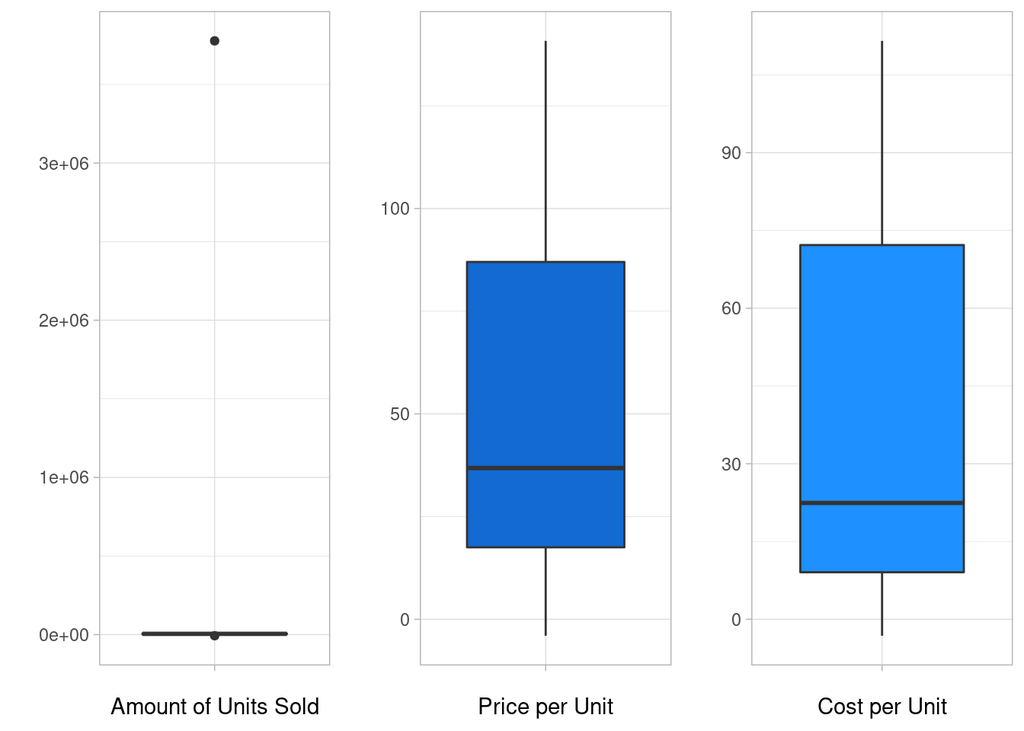

```r
# boxplot for Amount of Units Sold
plot_units_sold <- ggplot(total_sales) +
  aes(x = '', y = units_sold) +
  geom_boxplot(fill = '#00308F') +
  labs(x='Amount of Units Sold', y='') +
  theme_light()

# boxplot for Price per Unit
plot_unit_price <- ggplot(total_sales) +
  aes(x = '', y = unit_price) +
  geom_boxplot(fill = '#126AD2') +
  labs(x='Price per Unit', y='') +
  theme_light()

# boxplot for Cost per Unit
plot_unit_cost <- ggplot(total_sales) +
  aes(x = '', y = unit_cost) +
  geom_boxplot(fill = '#1E90FF') +
  labs(x='Cost per Unit', y='') +
  theme_light()

# arrange our boxplots side by side
grid.arrange(plot_units_sold, plot_unit_price, plot_unit_cost, ncol=3)
```

```r
summary(total_sales$units_sold)
```

```
##    Min. 1st Qu.  Median    Mean 3rd Qu.    Max.
##   -6897    2450    5064    6556    7498 3777000
```

```r
summary(total_sales$unit_price)
```

```
##    Min. 1st Qu.  Median    Mean 3rd Qu.    Max.
##  -4.014  17.506  36.812  54.235  86.980 140.814
```

```r
summary(total_sales$unit_cost)
```

```
##    Min. 1st Qu.  Median    Mean 3rd Qu.    Max.
##  -3.176   9.068  22.437  38.628  72.183 111.572
```

We identify several negative inputs. Stakeholders confirm a minus sign was accidentally added and those inputs should be positive.

```r
# convert values to absolute values
total_sales$units_sold <- abs(total_sales$units_sold)
total_sales$unit_price <- abs(total_sales$unit_price)
total_sales$unit_cost <- abs(total_sales$unit_cost)
```

We see one outlier at the amount of sold units. The stakeholder confirms that three zeros were accidentally added. We update to the right amount.

```r
# divide the max outlier by 1000 to remove three zeros
total_sales['units_sold'][total_sales['units_sold'] == max(total_sales$units_sold)] <- max(total_sales$units_sold)/1000
```

We now look at typos for string variables.

```r
count(total_sales, item_type)
```

```
##          item_type   n
## 1        Baby Food 215
## 2        Beverages 220
## 3           Cereal 162
## 4          Clothes 184
## 5        Cosmetics 203
## 6           Fruits 226
## 7        Household 212
## 8             Meat 198
## 9  Office Supplies 211
## 10   Personal Care 184
## 11          Snacks 191
## 12      Vegetables 200
```

```r
count(total_sales, region)
```

```
##                              region   n
## 1                              Asia 464
## 2             Australia and Oceania 199
## 3 Central America and the Caribbean 240
## 4                            Eruope   1
## 5                            Europe 803
## 6                            France   1
## 7      Middle East and North Africa 236
## 8                     North Amercia   1
## 9                     North America 461
```

Let’s fix typos appearing in “region”. No typos found in “item_type”.

```r
total_sales['region'][total_sales['region'] == 'North Amercia'] <- 'North America'
total_sales['region'][total_sales['region'] == 'Eruope'] <- 'Europe'
total_sales['region'][total_sales['region'] == 'France'] <- 'Europe'
```

Furthermore, we update names to be shorter.

```r
total_sales['region'][total_sales['region'] == 'Australia and Oceania'] <- 'Oceania'
total_sales['region'][total_sales['region'] == 'Central America and the Caribbean'] <- 'Central America'
total_sales['region'][total_sales['region'] == 'Middle East and North Africa'] <- 'Middle East'
```

### (5) Convert date columns from string to date format

```r
# convert string to date format as month/day/year
total_sales$order_date <- mdy(total_sales$order_date)
total_sales$ship_date <- mdy(total_sales$ship_date)
```

```r
# sort dataframe based on descending order dates
total_sales <- total_sales %>%
  arrange(desc(order_date))
```

### (6) Add calculated fields

We add new columns such as total revenue, cost and profit. This will help us for further analysis.

```r
# calculate Total Revenue, Total Cost and Total Profit for each observation
total_sales <- total_sales %>%
  mutate(total_revenue = units_sold*unit_price) %>%
  mutate(total_cost = units_sold*unit_cost) %>%
  mutate(total_profit = total_revenue - total_cost)
```

### (7) Add extra variables if further analysis is needed. *This is optional.*

Dates are too granular to analyse trends. We aggregate dates of orders into a new column.

```r
# aggregate dates under quarters
total_sales <- total_sales %>%
  mutate(order_qtr = quarter(order_date, with_year = T))
```

We add a new calculated field as “preparation_time” for showing the duration between receiving and shipping orders.

```r
# subtract Ship Date to Order Date to get the duration of order preparation
total_sales$preparation_time <- difftime(total_sales$ship_date, total_sales$order_date, units = c('days'))
```

## STEP 4 : Analyse and visualize the data

### (1) Describe variables

```r
# use count to describe string
count(total_sales, region)
```

```
##            region   n
## 1            Asia 464
## 2 Central America 240
## 3          Europe 805
## 4     Middle East 236
## 5   North America 462
## 6         Oceania 199
```

```r
count(total_sales, item_type)
```

```
##          item_type   n
## 1        Baby Food 215
## 2        Beverages 220
## 3           Cereal 162
## 4          Clothes 184
## 5        Cosmetics 203
## 6           Fruits 226
## 7        Household 212
## 8             Meat 198
## 9  Office Supplies 211
## 10   Personal Care 184
## 11          Snacks 191
## 12      Vegetables 200
```

```r
# use summary to describe float or integer
summary(total_sales$units_sold)
```

```
##    Min. 1st Qu.  Median    Mean 3rd Qu.    Max.
##       2    2455    5064    4993    7498    9985
```

```r
summary(total_sales$unit_price)
```

```
##    Min. 1st Qu.  Median    Mean 3rd Qu.    Max.
##   0.366  17.506  36.812  54.251  86.980 140.814
```

```r
summary(total_sales$unit_cost)
```

```
##    Min. 1st Qu.  Median    Mean 3rd Qu.    Max.
##   0.358   9.068  22.437  38.636  72.183 111.572
```

```r
summary(total_sales$total_revenue)
```

```
##      Min.   1st Qu.    Median      Mean   3rd Qu.      Max.
##       2.6   50136.2  156509.2  269453.4  375266.1 1338163.8
```

```r
summary(total_sales$total_cost)
```

```
##      Min.   1st Qu.    Median      Mean   3rd Qu.      Max.
##       3.4   31067.1   94598.0  191989.3  247937.6 1062381.1
```

```r
summary(total_sales$total_profit)
```

```
##    Min. 1st Qu.  Median    Mean 3rd Qu.    Max.
##  -30974   15866   54495   77464  115328  365073
```

### (2) Confirm the time frame of our data collection

```r
message("Data was collected from ", min(total_sales$order_date), " to ", max(total_sales$order_date))
```

```
## Data was collected from 2017-01-01 to 2020-07-28
```

We calculate a new variable as the time difference in year between first and last observations. It will be used later in the analysis to find average annual revenue and profit.

```r
year_diff <- time_length(difftime(max(total_sales$order_date), min(total_sales$order_date)), unit="years")
```

### (3) Look at an overview of sales

We show regions and their average annual revenue.

```r
# calculate average annual Revenue, grouped by Region
revenue_by_region <- total_sales %>%
  select(region, total_revenue) %>%
  group_by(region) %>%
  summarize(avg_annual_revenue = sum(total_revenue)/year_diff) %>%
  arrange(desc(avg_annual_revenue))

kable(revenue_by_region, col.names = c('Region', 'Average annual revenue ($)'))
```

| Region | Average annual revenue ($) |
| --- | --- |
| Europe | 57450118 |
| North America | 40907081 |
| Asia | 34676075 |
| Central America | 18850002 |
| Oceania | 15160806 |
| Middle East | 14545892 |

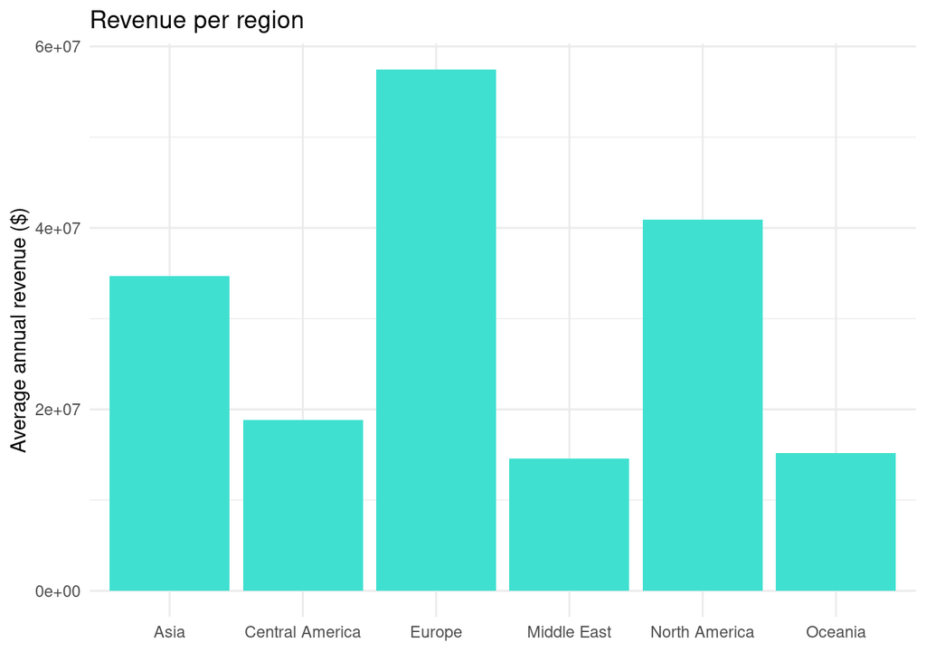

```r
# visualize average annual Revenue by Region
ggplot(revenue_by_region) +
  aes(x=region, y=avg_annual_revenue) +
  geom_col(fill = '#40E0D0') +
  labs(title='Revenue per region', x=element_blank(), y='Average annual revenue ($)') +
  theme_minimal()
```

We show product categories and their average annual revenue.

```r
# calculate average annual Revenue, grouped by Item Type
revenue_by_item_type <- total_sales %>%
  select(item_type, total_revenue) %>%
  group_by(item_type) %>%
  summarize(avg_annual_revenue = sum(total_revenue)/year_diff) %>%
  mutate(avg_annual_revenue = round(avg_annual_revenue, digits = 0)) %>%
  arrange(desc(avg_annual_revenue))

kable((revenue_by_item_type[ , ]), col.names = c('Category', 'Average annual revenue ($)'))
```

| Category | Average annual revenue ($) |
| --- | --- |
| Office Supplies | 39924124 |
| Household | 39748911 |
| Cosmetics | 23604190 |
| Meat | 22441696 |
| Baby Food | 15771992 |
| Cereal | 9322545 |
| Vegetables | 8645636 |
| Snacks | 7952906 |
| Clothes | 5964846 |
| Personal Care | 4357901 |
| Beverages | 3082804 |
| Fruits | 772422 |

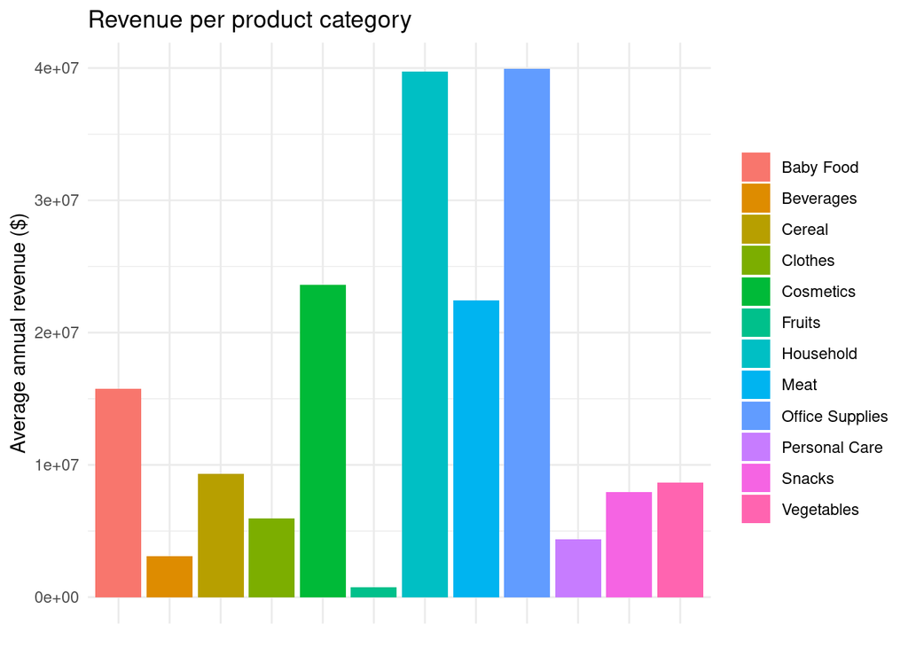

```r
# visualize average annual Revenue by Item Type
ggplot(revenue_by_item_type) +
  aes(x=item_type, y=avg_annual_revenue, fill=item_type) +
  geom_col() +
  labs(title='Revenue per product category', x=element_blank(), y='Average annual revenue ($)') +
  theme_minimal() +
  theme(axis.text.x = element_blank(), legend.title = element_blank())
```

### (4) Analyse sales by region and product category

We determine the average annual revenue by region and product category.

```r
# calculate average annual Revenue, grouped by Region and Item Type
revenue_region_item_type <- total_sales %>%
  select(region, item_type, total_revenue) %>%
  group_by(region, item_type) %>%
  summarize(avg_annual_revenue = sum(total_revenue)/year_diff) %>%
  mutate(avg_annual_revenue = round(avg_annual_revenue, digits =0 )) %>%
  arrange(region, desc(avg_annual_revenue))
```

```r
kable(head(revenue_region_item_type), caption = 'We only show the first 6 rows', col.names = c('Region', 'Category', 'Average annual revenue ($)'))
```

We only show the first 6 rows

| Region | Category | Average annual revenue ($) |
| --- | --- | --- |
| Asia | Household | 7664266 |
| Asia | Office Supplies | 6859093 |
| Asia | Meat | 5051143 |
| Asia | Cosmetics | 3931409 |
| Asia | Baby Food | 2972182 |
| Asia | Vegetables | 2333888 |

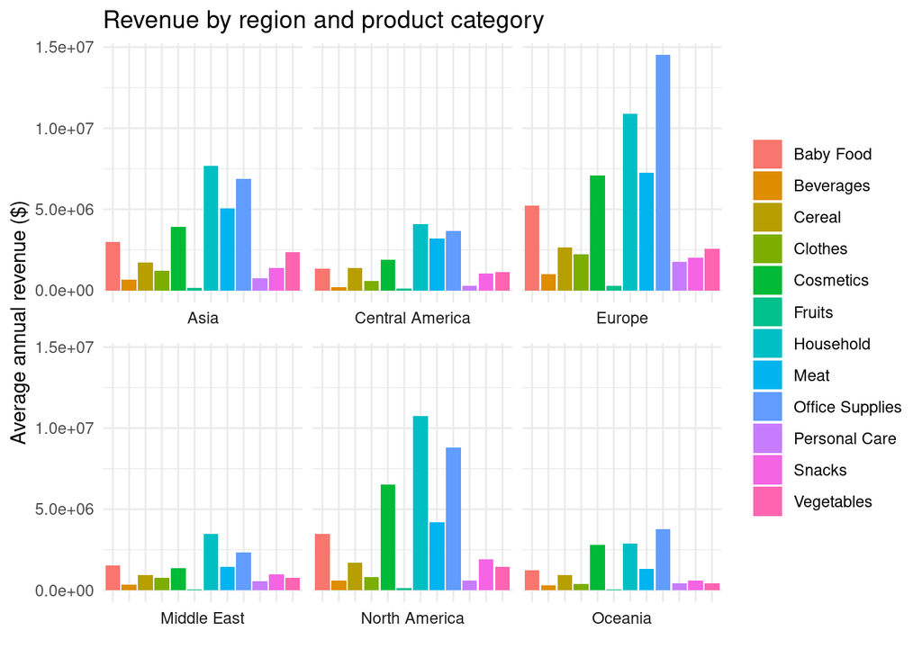

```r
# visualize average annual Revenue by Region and Item Type
ggplot(revenue_region_item_type) +
  aes(x=item_type, y=avg_annual_revenue, fill=item_type) +
  geom_col() +
  facet_wrap(~region, strip.position = 'bottom') +
  labs(title='Revenue by region and product category', x=element_blank(), y='Average annual revenue ($)') +
  theme_minimal() +
  theme(axis.text.x = element_blank(), legend.title = element_blank())
```

### (5) Look at the correlation between revenue and profit

High revenue doesn’t necessarily mean high profits. Let’s look at the correlation between those two variables.

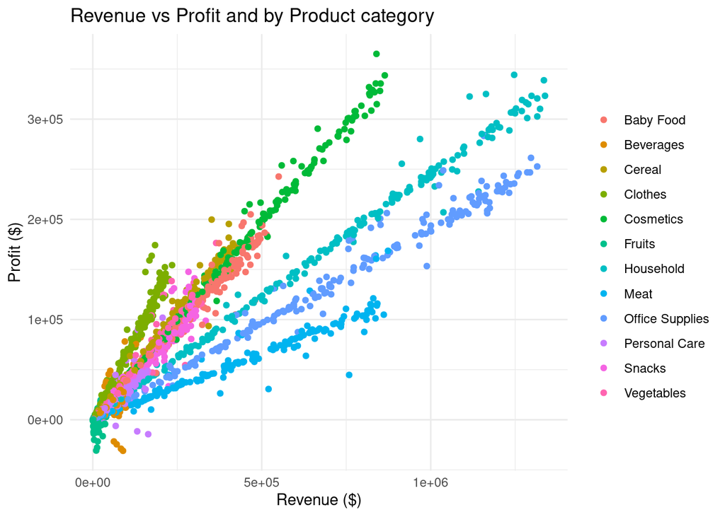

```r
# visualize correlation between Profit and Revenue and colored by Item Type
ggplot(total_sales) +
  aes(x=total_revenue, y=total_profit, color=item_type) +
  geom_point() +
  labs(title='Revenue vs Profit and by Product category', x='Revenue ($)', y='Profit ($)') +
  theme_minimal() +
  theme(legend.title = element_blank())
```

We see a positive correlation between revenue and profit. However, we see that certain product categories allow higher profits than others.

### (6) Analyse profit per region and product category

Let’s analyse our product categories in terms of profit using profit ratio.

```r
# calculate average annual Profit and Profit Ratio, grouped by Region and Item Type
profit_ratio_region_item_type <- total_sales %>%
  select(region, item_type, total_revenue, total_profit) %>%
  group_by(region, item_type) %>%
  summarize(avg_annual_revenue = sum(total_revenue/year_diff), avg_annual_profit = sum(total_profit/year_diff)) %>%
  mutate(avg_annual_revenue = round(avg_annual_revenue, digits =0), avg_annual_profit = round(avg_annual_profit, digits = 0), profit_ratio = round(avg_annual_profit/avg_annual_revenue*100, digits = 1)) %>%
  arrange(region, desc(profit_ratio))
```

```r
kable(head(profit_ratio_region_item_type), caption = 'We only show the first 6 rows', col.names = c('Region', 'Category', 'Average annual revenue', 'Average annual profit', 'Profit Ratio  (%)'))
```

We only show the first 6 rows

| Region | Category | Average annual revenue | Average annual profit | Profit Ratio (%) |
| --- | --- | --- | --- | --- |
| Asia | Clothes | 1209533 | 818340 | 67.7 |
| Asia | Cereal | 1718371 | 725798 | 42.2 |
| Asia | Cosmetics | 3931409 | 1539547 | 39.2 |
| Asia | Vegetables | 2333888 | 885742 | 38.0 |
| Asia | Snacks | 1396705 | 514234 | 36.8 |
| Asia | Baby Food | 2972182 | 1086521 | 36.6 |

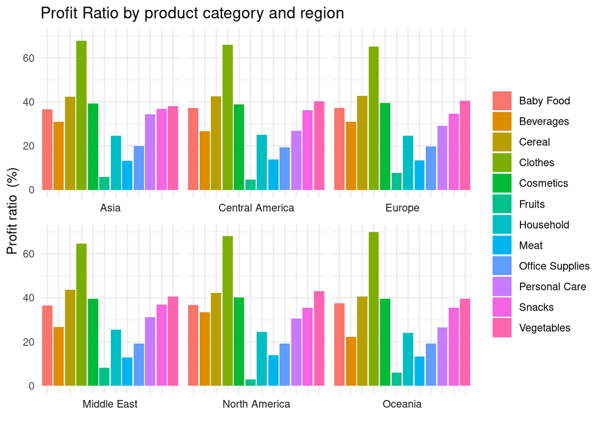

```r
# visualize Profit Ratio by Item Type and Region
ggplot(profit_ratio_region_item_type) +
  aes(x = item_type, y = profit_ratio, fill = item_type) +
  geom_col() +
  facet_wrap(~region, strip.position = 'bottom') +
  labs(title = 'Profit Ratio by product category and region', x = element_blank(), y = 'Profit ratio  (%)') +
  theme_minimal() +
  theme(axis.text.x = element_blank(), legend.title = element_blank())
```

### (7) Analyse best sellers

#### Best sellers based on revenue

To conclude, let’s see our three best sellers based on revenue and for each region.

```r
# identify top 3 Item Types in terms of Revenue, grouped by Region
bestsellers_revenue_region <- revenue_region_item_type %>%
  top_n(3)
```

```r
kable((bestsellers_revenue_region), col.names = c('Region', 'Category', 'Average annual revenue ($)'))
```

| Region | Category | Average annual revenue ($) |
| --- | --- | --- |
| Asia | Household | 7664266 |
| Asia | Office Supplies | 6859093 |
| Asia | Meat | 5051143 |
| Central America | Household | 4087194 |
| Central America | Office Supplies | 3664855 |
| Central America | Meat | 3179690 |
| Europe | Office Supplies | 14510369 |
| Europe | Household | 10912023 |
| Europe | Meat | 7259902 |
| Middle East | Household | 3458973 |
| Middle East | Office Supplies | 2321921 |
| Middle East | Baby Food | 1548386 |
| North America | Household | 10728094 |
| North America | Office Supplies | 8792768 |
| North America | Cosmetics | 6520456 |
| Oceania | Office Supplies | 3775117 |
| Oceania | Household | 2898361 |
| Oceania | Cosmetics | 2798733 |

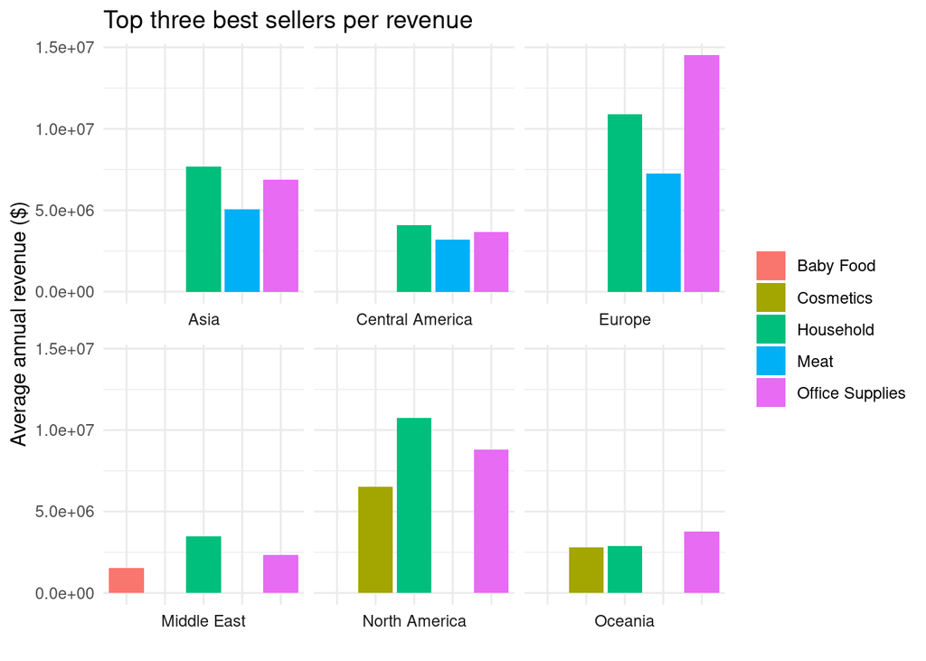

```r
# visualize top 3 Item Types in terms of Revenue grouped by Region
ggplot(bestsellers_revenue_region) +
  aes(x = item_type, y = avg_annual_revenue, fill = item_type) +
  geom_col()+
  facet_wrap(~region, strip.position = 'bottom') +
  labs(title = 'Top three best sellers per revenue', x = element_blank(), y = 'Average annual revenue ($)') +
  theme_minimal() +
  theme(axis.text.x = element_blank(), legend.title = element_blank())
```

#### Best sellers based on profit

To complete our conclusion, we should look at profit too.

```r
# identify top 3 Item Types in terms of Profit Ratio, grouped by Region
bestsellers_profit_ratio_region <- profit_ratio_region_item_type %>%
  top_n(3)
```

```r
kable((bestsellers_profit_ratio_region), col.names = c('Region', 'Category', 'Average annual revenue', 'Average annual profit', 'Profit Ratio(%)'))
```

| Region | Category | Average annual revenue | Average annual profit | Profit Ratio(%) |
| --- | --- | --- | --- | --- |
| Asia | Clothes | 1209533 | 818340 | 67.7 |
| Asia | Cereal | 1718371 | 725798 | 42.2 |
| Asia | Cosmetics | 3931409 | 1539547 | 39.2 |
| Central America | Clothes | 563970 | 371754 | 65.9 |
| Central America | Cereal | 1362611 | 577168 | 42.4 |
| Central America | Vegetables | 1142876 | 460249 | 40.3 |
| Europe | Clothes | 2221749 | 1443391 | 65.0 |
| Europe | Cereal | 2632425 | 1124961 | 42.7 |
| Europe | Vegetables | 2544763 | 1028156 | 40.4 |
| Middle East | Clothes | 781004 | 504748 | 64.6 |
| Middle East | Cereal | 929343 | 406292 | 43.7 |
| Middle East | Vegetables | 750589 | 304647 | 40.6 |
| North America | Clothes | 815583 | 554593 | 68.0 |
| North America | Vegetables | 1452412 | 624751 | 43.0 |
| North America | Cereal | 1721425 | 728411 | 42.3 |
| Oceania | Clothes | 373008 | 260883 | 69.9 |
| Oceania | Cereal | 958371 | 387966 | 40.5 |
| Oceania | Cosmetics | 2798733 | 1107426 | 39.6 |

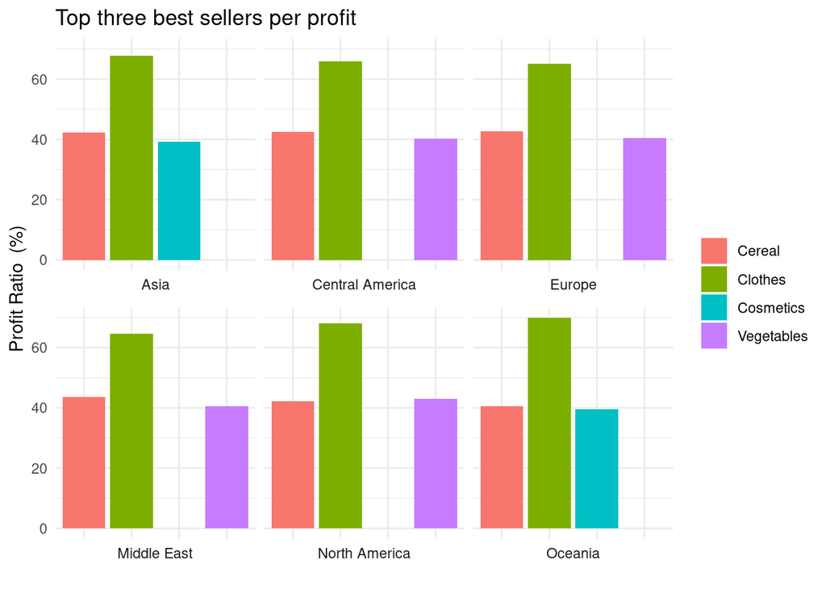

```r
# visualize top 3 Item Types in terms of Profit Ratio, grouped by Region
ggplot(bestsellers_profit_ratio_region) +
  aes(x = item_type, y = profit_ratio, fill = item_type) +
  geom_col()+
  facet_wrap(~region, strip.position = 'bottom') +
  labs(title = 'Top three best sellers per profit', x = element_blank(), y = 'Profit Ratio  (%)') +
  theme_minimal() +
  theme(axis.text.x = element_blank(), legend.title = element_blank())
```

#### Conclusion

As a final summary, we print out a table showing best sellers per region, revenue (showing as dollar), and including profit ratio (showing as percent).

```r
# create a new table, calculate average annual Revenue, average annual Profit and Profit Ratio, grouped by Region and Item Type
summary_sales_2017_2020 <- total_sales %>%
  select(region, item_type, total_revenue, total_profit) %>%
  group_by(region, item_type) %>%
  summarize(avg_annual_revenue = sum(total_revenue), avg_annual_profit = sum(total_profit)) %>%
  mutate(profit_ratio = round(avg_annual_profit/avg_annual_revenue, digits=2)) %>%
  arrange(region, desc(avg_annual_revenue))
```

We convert numerical values to currency or percent for better report comprehensiveness.

```r
# define the dollar format
dollar_format(prefix='$', suffix='', largest_with_cents=1e+05, big.mark=',', negative_parens=FALSE)

# convert variables to dollar format
summary_sales_2017_2020$avg_annual_revenue <- dollar(summary_sales_2017_2020$avg_annual_revenue)
summary_sales_2017_2020$avg_annual_profit <- dollar(summary_sales_2017_2020$avg_annual_profit)

# define percent format
percent_format(accuracy=0.1, scale=100, prefix='', suffix='%', big.mark='', decimal.mark='.', trim=FALSE)

# convert variables to percent format
summary_sales_2017_2020$profit_ratio <- percent(summary_sales_2017_2020$profit_ratio)
```

We then build the final report.

```r
kable(summary_sales_2017_2020, col.names = c('Region', 'Category', 'Average annual revenue', 'Average annual profit', 'Profit Ratio'))
```

| Region | Category | Average annual revenue | Average annual profit | Profit Ratio |
| --- | --- | --- | --- | --- |
| Asia | Household | $27,362,638 | $6,692,283 | 24.0% |
| Asia | Office Supplies | $24,488,042 | $4,851,446 | 20.0% |
| Asia | Meat | $18,033,377 | $2,382,436 | 13.0% |
| Asia | Cosmetics | $14,035,748 | $5,496,425 | 39.0% |
| Asia | Baby Food | $10,611,157 | $3,879,052 | 37.0% |
| Asia | Vegetables | $8,332,349 | $3,162,237 | 38.0% |
| Asia | Cereal | $6,134,856 | $2,591,213 | 42.0% |
| Asia | Snacks | $4,986,458 | $1,835,898 | 37.0% |
| Asia | Clothes | $4,318,223 | $2,921,603 | 68.0% |
| Asia | Personal Care | $2,615,910 | $897,865 | 34.0% |
| Asia | Beverages | $2,369,635 | $729,302 | 31.0% |
| Asia | Fruits | $510,654 | $29,731 | 6.0% |
| Central America | Household | $14,591,924 | $3,647,972 | 25.0% |
| Central America | Office Supplies | $13,084,109 | $2,507,743 | 19.0% |
| Central America | Meat | $11,351,992 | $1,562,588 | 14.0% |
| Central America | Cosmetics | $6,729,255 | $2,609,752 | 39.0% |
| Central America | Cereal | $4,864,735 | $2,060,582 | 42.0% |
| Central America | Baby Food | $4,785,813 | $1,775,145 | 37.0% |
| Central America | Vegetables | $4,080,247 | $1,643,161 | 40.0% |
| Central America | Snacks | $3,741,199 | $1,354,508 | 36.0% |
| Central America | Clothes | $2,013,463 | $1,327,219 | 66.0% |
| Central America | Personal Care | $1,019,761 | $273,057 | 27.0% |
| Central America | Beverages | $691,611 | $185,005 | 27.0% |
| Central America | Fruits | $343,366 | $15,943 | 5.0% |
| Europe | Office Supplies | $51,804,303 | $10,185,559 | 20.0% |
| Europe | Household | $38,957,641 | $9,542,260 | 24.0% |
| Europe | Meat | $25,918,995 | $3,447,818 | 13.0% |
| Europe | Cosmetics | $25,322,865 | $9,982,981 | 39.0% |
| Europe | Baby Food | $18,656,510 | $6,913,833 | 37.0% |
| Europe | Cereal | $9,398,170 | $4,016,287 | 43.0% |
| Europe | Vegetables | $9,085,204 | $3,670,678 | 40.0% |
| Europe | Clothes | $7,931,995 | $5,153,132 | 65.0% |
| Europe | Snacks | $7,216,034 | $2,492,640 | 35.0% |
| Europe | Personal Care | $6,242,909 | $1,811,933 | 29.0% |
| Europe | Beverages | $3,557,564 | $1,096,436 | 31.0% |
| Europe | Fruits | $1,013,775 | $76,787 | 8.0% |
| Middle East | Household | $12,349,079 | $3,137,105 | 25.0% |
| Middle East | Office Supplies | $8,289,625 | $1,595,066 | 19.0% |
| Middle East | Baby Food | $5,527,981 | $2,010,320 | 36.0% |
| Middle East | Meat | $5,144,029 | $660,028 | 13.0% |
| Middle East | Cosmetics | $4,911,834 | $1,938,538 | 39.0% |
| Middle East | Snacks | $3,471,441 | $1,285,275 | 37.0% |
| Middle East | Cereal | $3,317,900 | $1,450,525 | 44.0% |
| Middle East | Clothes | $2,788,306 | $1,802,031 | 65.0% |
| Middle East | Vegetables | $2,679,720 | $1,087,639 | 41.0% |
| Middle East | Personal Care | $1,985,376 | $622,013 | 31.0% |
| Middle East | Beverages | $1,242,335 | $333,332 | 27.0% |
| Middle East | Fruits | $223,498 | $18,177 | 8.0% |
| North America | Household | $38,300,984 | $9,388,063 | 25.0% |
| North America | Office Supplies | $31,391,567 | $6,029,570 | 19.0% |
| North America | Cosmetics | $23,279,054 | $9,344,353 | 40.0% |
| North America | Meat | $14,904,797 | $2,073,088 | 14.0% |
| North America | Baby Food | $12,359,949 | $4,550,979 | 37.0% |
| North America | Snacks | $6,844,792 | $2,431,946 | 36.0% |
| North America | Cereal | $6,145,757 | $2,600,542 | 42.0% |
| North America | Vegetables | $5,185,338 | $2,230,458 | 43.0% |
| North America | Clothes | $2,911,758 | $1,979,984 | 68.0% |
| North America | Personal Care | $2,164,381 | $663,119 | 31.0% |
| North America | Beverages | $2,083,392 | $698,070 | 34.0% |
| North America | Fruits | $472,948 | $13,617 | 3.0% |
| Oceania | Office Supplies | $13,477,761 | $2,585,696 | 19.0% |
| Oceania | Household | $10,347,604 | $2,485,426 | 24.0% |
| Oceania | Cosmetics | $9,991,919 | $3,953,684 | 40.0% |
| Oceania | Meat | $4,767,196 | $628,213 | 13.0% |
| Oceania | Baby Food | $4,367,086 | $1,635,701 | 37.0% |
| Oceania | Cereal | $3,421,535 | $1,385,098 | 40.0% |
| Oceania | Snacks | $2,133,204 | $757,202 | 35.0% |
| Oceania | Personal Care | $1,530,055 | $407,737 | 27.0% |
| Oceania | Vegetables | $1,503,423 | $593,498 | 39.0% |
| Oceania | Clothes | $1,331,697 | $931,394 | 70.0% |
| Oceania | Beverages | $1,061,559 | $237,048 | 22.0% |
| Oceania | Fruits | $193,427 | $11,417 | 6.0% |

## STEP 5 : Save the final report

Export our dataframe to a csv file for archives or further analysis.

```r
write.table(x = summary_sales_2017_2020, file = '/cloud/project/BlueIsland/summary_sales_2017_2020.csv')
```

## STEP 6 : Plan for further analysis

We can perform further analysis such as look at trends over the time for product categories and regions. We can as well analyse sales per country rather than only region giving us an even more detailed picture.

Thank you for reading my case study. Feel free to contact me if you have any remarks or questions at : alexandre.kocev@gmail.com

Have a lovely day ahead.